# HW4

Yujia Hao_504702886

6/3/2017

## Introduction

I got the data from UCI Machine Learning Repository website https://archive.ics.uci.edu/ml/datasets/adult. The dataset includes 48842 instances, 14 attributes, and the charactereistics of attributes are categorical and integer, which includes age, workclass,education, and so on. I chose class, which represents the income less than 50K and more than 50K, as my binary variable to study in this report.The purpose of this study is to explore the possibility in predicting income level based on the individual’s personal information. First of all, I downloaded the original train and test dataset, and merged them to achieve a dataset that contains at least 10000 positive and 10000 negative examples. Then, I cleaned the data by skipping the null values, and look for the dimension of income less than 50K and more than 50K, which are 37155, 11687 respectively.

```r
temp <- tempfile()
download.file("https://archive.ics.uci.edu/ml/machine-learning-databases/adult/adult.data",temp)
mydata <- read.csv(temp, fill = TRUE, header=FALSE,skipNul = TRUE)
unlink(temp)
temp2 <- tempfile()
download.file("https://archive.ics.uci.edu/ml/machine-learning-databases/adult/adult.test",temp2)
mydata2 <- read.csv(temp2, skip = 1, fill = TRUE, header=FALSE,skipNul = TRUE)
unlink(temp2)
mydat <- rbind(mydata,mydata2)
values <- c("age","workclass","fnlwgt", "education", "education_num", "marital_status", "occupation", "relationship", "race", "sex", "capital_gain", "capital_loss", "hours_per_week", "native_country", "class")
names(mydat) <- values
head(mydat)
```

```
##   age         workclass fnlwgt  education education_num
## 1  39         State-gov  77516  Bachelors            13
## 2  50  Self-emp-not-inc  83311  Bachelors            13
## 3  38           Private 215646    HS-grad             9
## 4  53           Private 234721       11th             7
## 5  28           Private 338409  Bachelors            13
## 6  37           Private 284582    Masters            14
##        marital_status         occupation   relationship   race     sex
## 1       Never-married       Adm-clerical  Not-in-family  White    Male
## 2  Married-civ-spouse    Exec-managerial        Husband  White    Male
## 3            Divorced  Handlers-cleaners  Not-in-family  White    Male
## 4  Married-civ-spouse  Handlers-cleaners        Husband  Black    Male
## 5  Married-civ-spouse     Prof-specialty           Wife  Black  Female
## 6  Married-civ-spouse    Exec-managerial           Wife  White  Female
##   capital_gain capital_loss hours_per_week native_country  class
## 1         2174            0             40  United-States  <=50K
## 2            0            0             13  United-States  <=50K
## 3            0            0             40  United-States  <=50K
## 4            0            0             40  United-States  <=50K
## 5            0            0             40           Cuba  <=50K
## 6            0            0             40  United-States  <=50K
```

```r
library(dplyr)
mydat$class <- as.character(mydat$class)
mydat$class[mydat$class == " <=50K."] <- " <=50K"
mydat$class[mydat$class == " >50K."] <- " >50K"
mydat$class <- as.factor(mydat$class)
write.csv(mydat, file = "mydata.csv", row.names = FALSE)
```

## Explore Categorical Data

In this part of study, I chose 4 categorical variables to visualize, workclass, education, marial status, and sex. Therefore, we will get to clear about the variables and have a rough visialization about the dataset.

#### Work class

[figure not shown]

#### Education

According to the education plot, there is a trend that the higher education people achieved, the more money they make. Most of people achieved High School Grad, and some college.The proportion of Doctorate and Prof-school is the highest in earning more than 50K.

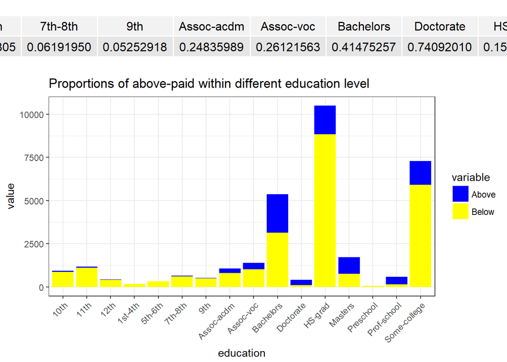

#### Marital Status

According to the plot, we can see that people married with a spouse have a higher proportion of earning more than 50K than other groups, which may have a relationship with age.

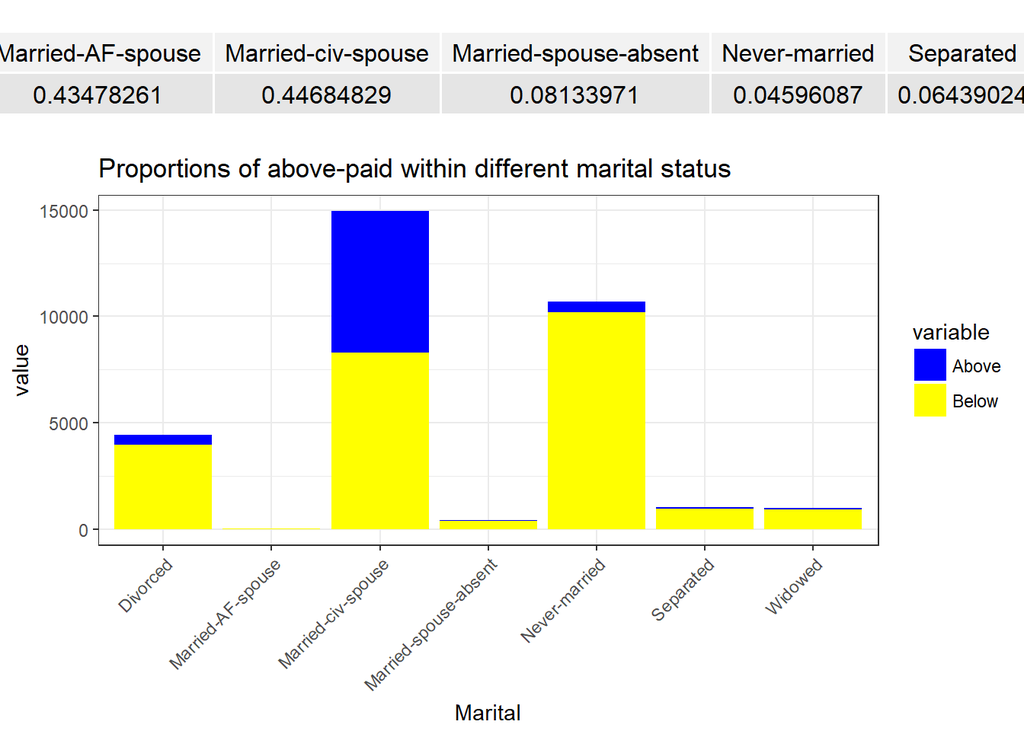

#### Sex

According to the plot, the portion of male earning more than 50k is larger than female, also, the proportion of male earning more than 50k is also larger than female.

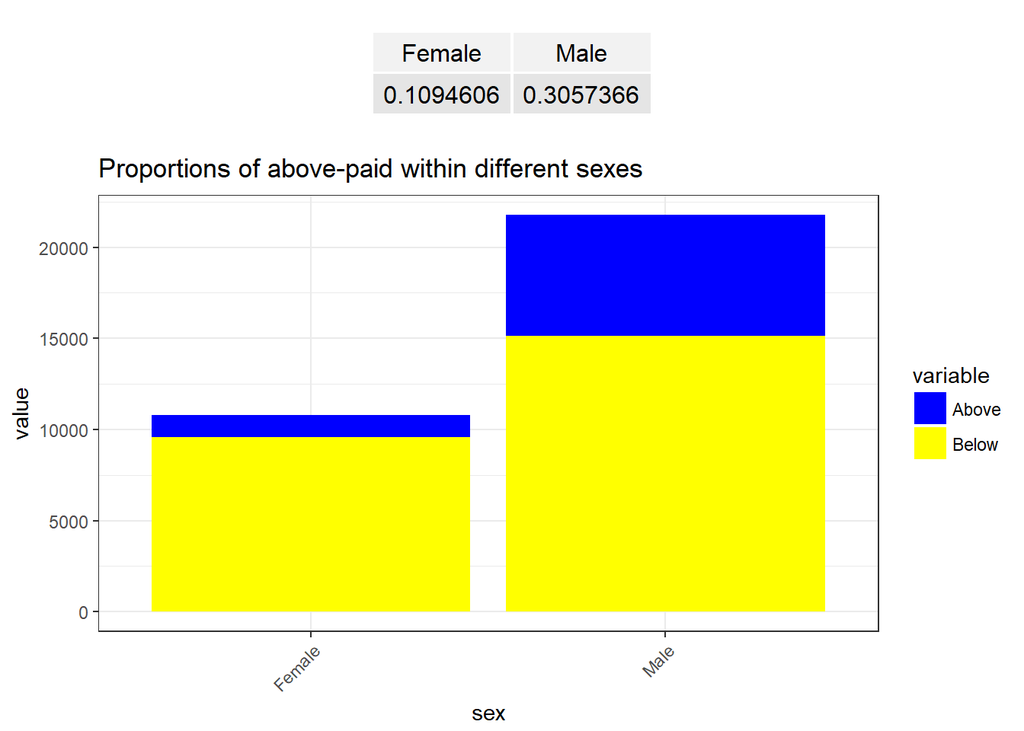